# DN2_Matjaz

Urban Matjaz

2024-12-31

# 1. Kako velikost vzorca vpliva na diagnostiko grafov ostankov?

Pri manjših vzorcih je variabilnost večja, zaradi česar je težko razločiti med naključnim šumom in dejanskimi problemi v modelu. Prav tako imajo posamične točke v manjših vzorcih večji vpliv in posledično lahko pripeljejo do napačnih zaključkov.

# 2. Kako na grafu ostankov zaznamo prisotnost heteroskedastičnosti?

Variabilnost ostankov se pri večjih ocenjenih vrednostih veča ali manjša, torej ni enakomerna pri vseh napovednih vrednostih.

## Primer heteroskedastičnih podatkov

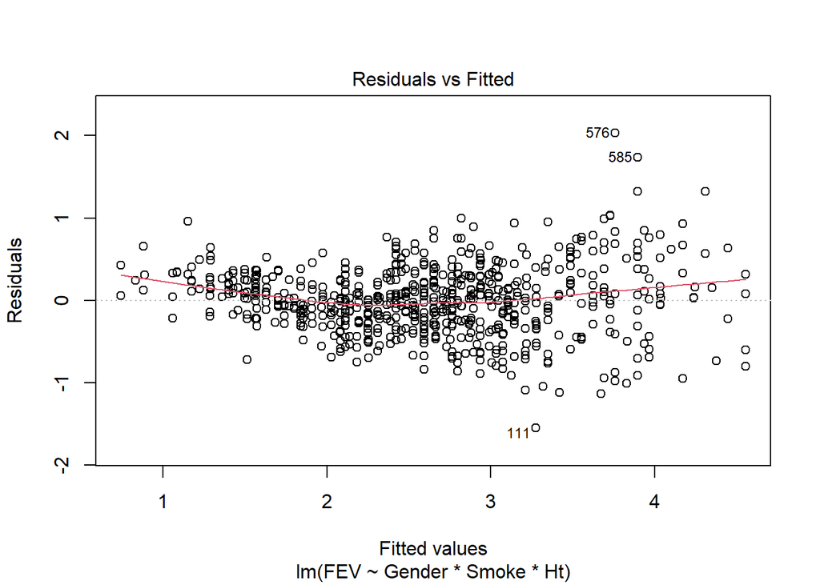

# 3. Kako na grafu opazimo, da ostanki niso porazdeljeni normalno?

Na Q-Q plotu so na x osi predstavljeni teoretični kvantili iz normalne porazdelitve na y osi pa dejanski kvantili ostankov iz našega primera. V primeru, da so ostanki na grafu v obliki črke S to kaže na asimetrijo porazdelitve ostankov. Če se ostanki oddaljujejo od diagonale na koncih to kaže na preveliko število prevelikih ostankov.

# 4. Na kaj vpliva heteroskedastičnost?

Heteroskedastičnost vpliva na:

- Standardne napake regresijskih koeficientov
- Intervale zaupanja regresijskih koeficientov
- Mere prileganja modela (R^2…)

# 5. S simulacijami pokažite, kaj kaj se zgodi z velikostjo testa v primeru kršitve predpostavke o konstantni varianci.

```r
set.seed(64220387)

velikost_testa = function(hts = FALSE, n_sim = 1000, n = 50, alpha = 0.05, beta_0 = 0, beta_1 = 0) {
  stev_zavrnitev = 0
  for (i in 1:n_sim) {
    x = runif(n, 0, 10)

    if (hts) {
      eps = rnorm(n, mean = 0, sd = 0.5 + 0.1 * x)
    } else {
      eps = rnorm(n)
    }

    y = beta_0 + beta_1 * x + eps
    model = lm(y ~ x)
    p_value = summary(model)$coefficients[2, 4]
    if (p_value < alpha) {
      stev_zavrnitev = stev_zavrnitev + 1
    }
  }
  return(stev_zavrnitev / n_sim)
}

velikost_homoskedasticnost = velikost_testa(hts = FALSE, beta_0 = 5) # beta_0 nima vpliva na rezultat
velikost_heteroskedasticnost = velikost_testa(hts = TRUE, beta_0 = 5)

rez <- data.frame(Predpostavka = c("Homoskedastičnost", "Heteroskedastičnost"), "Velikost testa" = c(velikost_homoskedasticnost, velikost_heteroskedasticnost))

kable(rez, caption = "Vpliv heteroskedastičnosti na velikost testa")
```

Vpliv heteroskedastičnosti na velikost testa

| Predpostavka | Velikost.testa |
| --- | --- |
| Homoskedastičnost | 0.058 |
| Heteroskedastičnost | 0.069 |

Opazimo, da se v primeru heteroskedastičnosti velikost testa poveča, kar pomeni, da je test preveč liberalen in posledično prevečkrat zavrnemo ničelno domnevo tudi kadar ne moremo trditi, da le ta ne drži.